# Introduction to Open Data Science

# Chapter 3 Logistic regression

*Summary of the week (completed work and learning)*

In this Chapter we work on data from two questionnaires related to student performance (especially including alcohol consumption). We cover two parts: (1) data wrangling and (2) data analysis with logistic regression.

- In data wrangling, we join two data sets together and create an analysis dataset (.csv file) using an R script.
- In data analysis, we study the relationships between high/low alcohol consumption and some of the other variables in the data.
- This report follows the following logic: R script used –> ouputs –> explanations.

### Part 1: data wrangling

We join two data sets together and create an analysis dataset for the analysis exercise. To produce the dataset, see **create_alc.R** file in the folder **data** here: https://github.com/alfanmansur/IODS-project/tree/master/data. And the dataset produced is **data_alc.csv** file in the same folder.

### Part 2: data analysis with logistic regression

In this part, We use the following R packages to produce the intended outputs:

```r
library(janitor) # this is to do cross tabulations
library(ggplot2) # this is to produce bar and box-plots, together with the next one.
library(ggpubr)  # this is to combine plots in one frame
library(dplyr)
library(caret)   # this is to perform cross validations
```

We then proceed by firstly run the R script, print some outputs and then read the outputs.

## 3.1 Explore the data

We start with exploring the dataset including its structure and summary.

```r
# Read the data from my local folder
mydata <- read.csv('./data/data_alc.csv')

# Read the data from url link (only for checking purpose)
data <- read.csv("https://github.com/rsund/IODS-project/raw/master/data/alc.csv",
                 header = TRUE, sep = ",")
# Comparing those two datasets, my constructed dataset is just exactly the same as the dataset given in the link, except the variables ending with ".p" or ".m" which I don't include in my dataset as we don't need them for analysis.

colnames(mydata)  #to see the names of all variables in the dataset
```

```
##  [1] "school"     "sex"        "age"        "address"    "famsize"
##  [6] "Pstatus"    "Medu"       "Fedu"       "Mjob"       "Fjob"
## [11] "reason"     "guardian"   "traveltime" "studytime"  "schoolsup"
## [16] "famsup"     "activities" "nursery"    "higher"     "internet"
## [21] "romantic"   "famrel"     "freetime"   "goout"      "Dalc"
## [26] "Walc"       "health"     "failures"   "paid"       "absences"
## [31] "G1"         "G2"         "G3"         "alc_use"    "high_use"
```

```r
summary <- summary(mydata)   #to see the summary of each variable, but is unnecessary to display all the details in the report
str(mydata)      #to see the data structure
```

[output not shown]

**Brief description about the dataset**

The original source of the data is here: https://archive.ics.uci.edu/ml/datasets/Student+Performance. This data approach student achievement in secondary education of two Portuguese schools. The data attributes include student grades, demographic, social and school related features) and it was collected by using school reports and questionnaires. Two datasets are provided regarding the performance in two distinct subjects: Mathematics (mat) and Portuguese language (por) which then we join the two datasets becoming one dataset as we use for the analysis in the next section. There are originally 33 attributes and then we construct 2 additional attributes, i.e. (1) alcohol consumption which is the average of the answers related to weekday and weekend alcohol consumption, and (2) logical class of data for attribute of high consumption of alcohol defined by attribute of alcohol consumption >2. Altogether, we have 370 observations of 35 attributes. The detail description of the original 33 attributes can be seen in the provided link.

## 3.2 Explore the distributions of the variables

To study the relationships between high/low alcohol consumption and some of the other variables, we start with choosing 4 variables from the dataset and we present our personal hypothesis about their relationships with alcohol consumption. **First**, *age*, our hypothesis is that the younger the student is, the more he/she will consume alcohol as the ages range between 15-22 years old. Teenagers usually are curious to try many things. **Second**, *famrel (quality of family relationships)*, our hypothesis is that the higher quality, the less a student consumes alcohol since he/she will have more time spent with family. Third, *goout (going out with friends)*, our hypothesis is that the more frequent going out with friends, the more consumption of alcohol is. Finally, *health (current health status)*, our hypothesis is that a student with a bad health condition will consume less alcohol.

Let’s now we numerically and graphically explore the distributions of the chosen variables and their relationships with alcohol consumption using:  
1. cross-tabulations, and  
2. bar and box plots.

The Cross-tabulations of alcohol consumption with age given below counts the amount of alcohol consumed per age. It indicates that students 15-17 years old consume more alcohol than older students and students aged 17 has the highest level of high alcohol consumption (>2). More or less, this is in line with our hypothesis previously.

```r
#tabyl(mydata, age, alc_use, high_use) %>%
#  adorn_percentages("row") %>%
#  adorn_pct_formatting(digits = 2)
tabyl(mydata, age, alc_use, high_use)
```

```
## $`FALSE`
##  age  1 1.5  2 2.5 3 3.5 4 4.5 5
##   15 46   9  8   0 0   0 0   0 0
##   16 40  20 14   0 0   0 0   0 0
##   17 25  19 18   0 0   0 0   0 0
##   18 25  12 15   0 0   0 0   0 0
##   19  3   3  1   0 0   0 0   0 0
##   20  1   0  0   0 0   0 0   0 0
##   22  0   0  0   0 0   0 0   0 0
##
## $`TRUE`
##  age 1 1.5 2 2.5 3 3.5 4 4.5 5
##   15 0   0 0   8 4   3 2   0 1
##   16 0   0 0   9 9   3 4   0 3
##   17 0   0 0  16 8   5 2   2 2
##   18 0   0 0   7 8   6 1   1 2
##   19 0   0 0   1 3   0 0   0 0
##   20 0   0 0   0 0   0 0   0 0
##   22 0   0 0   0 0   0 0   0 1
```

```r
tabyl(mydata, famrel, alc_use, high_use)
```

```
## $`FALSE`
##  famrel  1 1.5  2 2.5 3 3.5 4 4.5 5
##       1  2   2  2   0 0   0 0   0 0
##       2  6   1  2   0 0   0 0   0 0
##       3 17  12 10   0 0   0 0   0 0
##       4 70  27 31   0 0   0 0   0 0
##       5 45  21 11   0 0   0 0   0 0
##
## $`TRUE`
##  famrel 1 1.5 2 2.5  3 3.5 4 4.5 5
##       1 0   0 0   0  0   0 1   0 1
##       2 0   0 0   4  2   2 0   0 1
##       3 0   0 0  12  9   2 1   0 1
##       4 0   0 0  19 14   8 5   2 4
##       5 0   0 0   6  7   5 2   1 2
```

```r
tabyl(mydata, goout, alc_use, high_use)
```

```
## $`FALSE`
##  goout  1 1.5  2 2.5 3 3.5 4 4.5 5
##      1 14   3  2   0 0   0 0   0 0
##      2 49  20 13   0 0   0 0   0 0
##      3 44  28 25   0 0   0 0   0 0
##      4 24   7  9   0 0   0 0   0 0
##      5  9   5  7   0 0   0 0   0 0
##
## $`TRUE`
##  goout 1 1.5 2 2.5  3 3.5 4 4.5 5
##      1 0   0 0   2  0   1 0   0 0
##      2 0   0 0   7  4   2 0   1 1
##      3 0   0 0  13  3   4 1   0 2
##      4 0   0 0  15 14   3 5   1 0
##      5 0   0 0   4 11   7 3   1 6
```

Finally, the cross-tabulations of alcohol consumption with health given below show that higher level of health is associated with higher consumption of alcohol which is in line with our hypothesis.

```r
tabyl(mydata, health, alc_use, high_use)
```

```
## $`FALSE`
##  health  1 1.5  2 2.5 3 3.5 4 4.5 5
##       1 20   8  7   0 0   0 0   0 0
##       2 13   6  9   0 0   0 0   0 0
##       3 35  17  9   0 0   0 0   0 0
##       4 27   9  9   0 0   0 0   0 0
##       5 45  23 22   0 0   0 0   0 0
##
## $`TRUE`
##  health 1 1.5 2 2.5  3 3.5 4 4.5 5
##       1 0   0 0   3  4   1 2   0 1
##       2 0   0 0   7  4   2 1   0 0
##       3 0   0 0  10  2   3 1   2 1
##       4 0   0 0   6  4   2 1   0 4
##       5 0   0 0  15 18   9 4   1 3
```

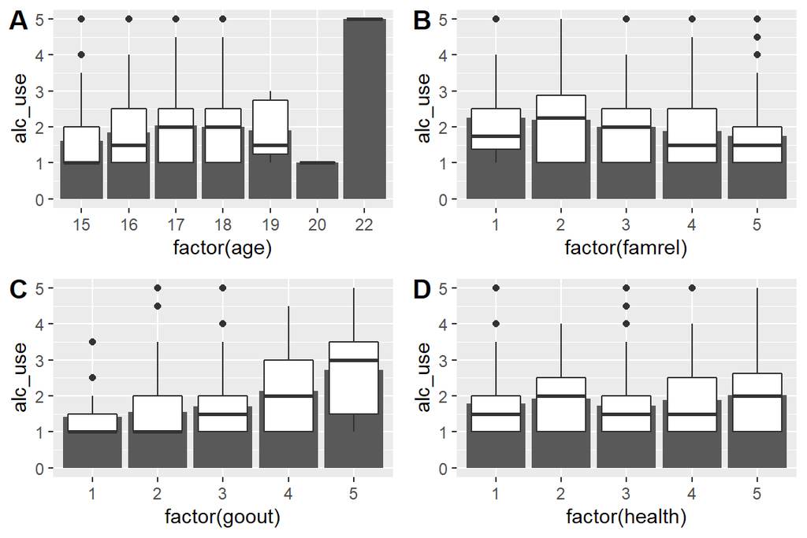

```r
# First, the plots of alcohol consumption and age
temp <- mydata %>% group_by(age = factor(age)) %>% summarise(alc_use = mean(alc_use))
a <- ggplot(mydata, aes(factor(age), alc_use)) + geom_bar(data = temp, aes(age, alc_use), stat = "identity") + geom_boxplot()

# Second, the plots of alcohol consumption and family relation
temp <- mydata %>% group_by(famrel = factor(famrel)) %>% summarise(alc_use = mean(alc_use))
b <- ggplot(mydata, aes(factor(famrel), alc_use)) + geom_bar(data = temp, aes(famrel, alc_use), stat = "identity") + geom_boxplot()

# Third, the plots of alcohol consumption and 'go out with friends'
temp <- mydata %>% group_by(goout = factor(goout)) %>% summarise(alc_use = mean(alc_use))
c <- ggplot(mydata, aes(factor(goout), alc_use)) + geom_bar(data = temp, aes(goout, alc_use), stat = "identity") + geom_boxplot()

# Fourth, the plots of alcohol consumption and health condition
temp <- mydata %>% group_by(health = factor(health)) %>% summarise(alc_use = mean(alc_use))
d <- ggplot(mydata, aes(factor(health), alc_use)) + geom_bar(data = temp, aes(health, alc_use), stat = "identity") + geom_boxplot()

ggarrange(a, b, c, d,
          labels = c("A", "B", "C", "D"),
          ncol = 2, nrow = 2)
```

## 3.3 Fit a logistic regression model

Our target (dependent) variable is the high consumption of alcohol and our regressors are the four variables of age, famrel, goout, health. The following R code estimates a logistic regression model using the glm (generalized linear model) function.

```r
model <- glm( high_use ~ age + famrel + goout + health, data = mydata, family = binomial)
summary(model)
```

```
##
## Call:
## glm(formula = high_use ~ age + famrel + goout + health, family = binomial,
##     data = mydata)
##
## Deviance Residuals:
##     Min       1Q   Median       3Q      Max
## -1.5358  -0.7930  -0.5398   0.9776   2.4872
##
## Coefficients:
##             Estimate Std. Error z value Pr(>|z|)
## (Intercept) -4.72538    1.86902  -2.528  0.01146 *
## age          0.13695    0.10746   1.274  0.20252
## famrel      -0.44125    0.13888  -3.177  0.00149 **
## goout        0.78830    0.12070   6.531 6.53e-11 ***
## health       0.20040    0.09227   2.172  0.02986 *
## ---
## Signif. codes:  0 '***' 0.001 '**' 0.01 '*' 0.05 '.' 0.1 ' ' 1
##
## (Dispersion parameter for binomial family taken to be 1)
##
##     Null deviance: 452.04  on 369  degrees of freedom
## Residual deviance: 388.48  on 365  degrees of freedom
## AIC: 398.48
##
## Number of Fisher Scoring iterations: 4
```

To interpret the results above, we adopt some materials from: https://stats.idre.ucla.edu/r/dae/logit-regression/.

From the summary of the fitted model above, the Deviance Residuals (displayed above the coefficients) indicate the distribution of the deviance residuals for individual cases used in the model. Moreover, we can measure the model fit using the results of Null deviance and the Residual deviance (displayed below the coefficients). We can test the significance of the overall model by comparing to the null model, i.e. the model with an intercept only (without the predictors).

- First, we find the difference in deviance for the two competing models as for the test statistic as follows:

```r
with(model, null.deviance - deviance)
```

```
## [1] 63.55916
```

- The test statistic follows a chi-squared distribution with the degrees of freedom for the difference between the two competing models as follows:

```r
with(model, df.null - df.residual)
```

```
## [1] 4
```

- Then we can compute the p-value as:

```r
with(model, pchisq(null.deviance - deviance, df.null - df.residual, lower.tail = FALSE))
```

```
## [1] 5.174974e-13
```

- The chi-square of 63.56 with 4 degrees of freedom and a p-value of less than 0.001 shows that our model fits significantly better than an empty model or the null model.

Next we move to interpret the coefficients. Overall, together with the coefficients, the output also displays the standard errors, Wald z-statistic, and the p-values. From our four predictors, three are statistically significant, i.e. ‘famre’, ‘goout’, and ‘health’. The coefficients give the change in the log odds of the outcome for a one unit increase in the predictor variable.

To interpret the coefficients as odds-ratios as well as their confidence intervals, we need to exponentiate the coefficients as follows:

```r
exp(cbind(OR = coef(model), confint(model)))
```

```
##                     OR        2.5 %    97.5 %
## (Intercept) 0.00886738 0.0002156501 0.3367406
## age         1.14676965 0.9289914198 1.4179485
## famrel      0.64323452 0.4878244316 0.8425526
## goout       2.19966187 1.7472840445 2.8074492
## health      1.22189321 1.0225725528 1.4695035
```

We can interpret the odds-ratios as follows:

- For one unit increase in ‘famrel’, there is a 36% lower likelihood of having high consumption of alcohol. Within 95% confidence interval, there is 16%-51% lower the likelihood of having high consumption of alcohol. This result is in line with our previous hypothesis that the better family relationship is, the less alcohol consumed is, with argument that the student spends more time with family doing activities together.
- For one unit increase in ‘goout’, there is 2.20 times higher likelihood of having high consumption of alcohol. Within 95% confidence interval, the likelihood is 1.75-2.81 times higher. This is consistent with our hypothesis of more often going out with friends is associated with more consumption of alcohol.
- Lastly, for one unit increase in ‘health’, there is a 22% higher the likelihood of having high consumption of alcohol. Within 95% confidence interval, there is 2%-47% higher the likelihood of having high consumption of alcohol. This is also consistent with our hypothesis.

Next, we explore the predictive power of our model by provide a 2x2 cross tabulation of predictions versus the actual values and display a graphic visualizing both the actual values and the predictions.

```r
mydata$high_useP <- predict(model, newdata = mydata, type = "response")
mydata$high_useP = mydata$high_useP > 0.5
table(mydata$high_useP, mydata$high_use) #Produce 2x2 cross tabulation of predictions vs the actual values
```

```
##
##         FALSE TRUE
##   FALSE   235   67
##   TRUE     24   44
```

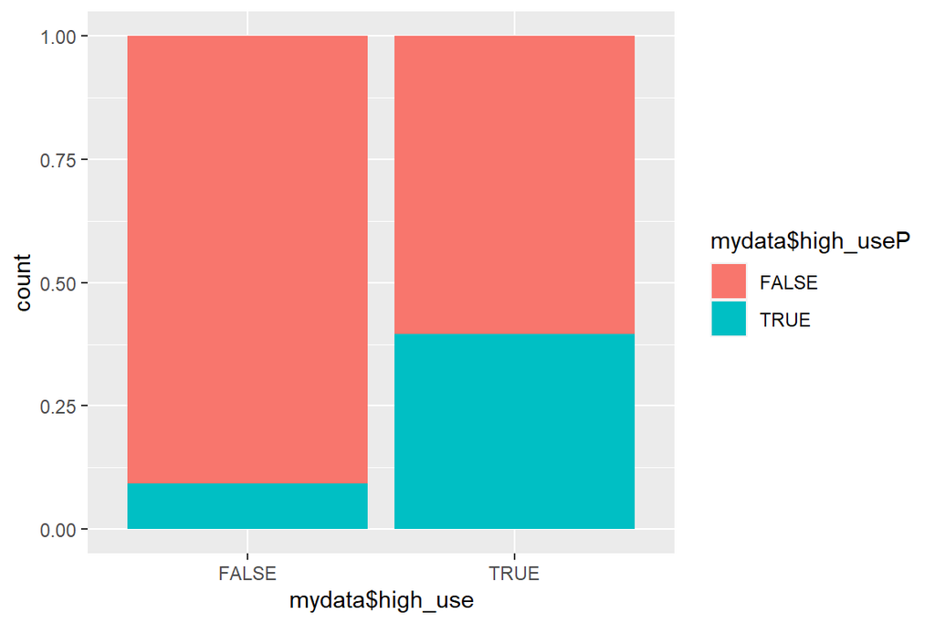

```r
df <- as.data.frame(cbind(mydata$high_use, mydata$high_useP))

ggplot(df,aes(x = mydata$high_use, fill = mydata$high_useP)) +
    geom_bar(position = "fill")
```

```r
high_use_simpleP <- mydata$famrel+mydata$goout+mydata$health > 7.5
table(high_use_simpleP, mydata$high_use) #Produce 2x2 cross tabulation of simple predictions vs the actual values
```

```
##
## high_use_simpleP FALSE TRUE
##            FALSE    23    3
##            TRUE    236  108
```

## 3.4. Perform 10-fold cross-validation on the model

Here we perform 10-fold cross-validation of the model using the ‘caret’ package in R as follows:

```r
# define training control
train_control <- trainControl(method = "cv", number = 10)

# train the model on training set
modelcv <- train(factor(high_use) ~ age + famrel + goout + health,
               data = mydata,
               trControl = train_control,
               method = "glm",
               family=binomial())

# print cv scores
modelcv
```

```
## Generalized Linear Model
##
## 370 samples
##   4 predictor
##   2 classes: 'FALSE', 'TRUE'
##
## No pre-processing
## Resampling: Cross-Validated (10 fold)
## Summary of sample sizes: 332, 333, 334, 333, 333, 333, ...
## Resampling results:
##
##   Accuracy   Kappa
##   0.7461317  0.3118018
```

In case we want to take into account the uncertainty in our accuracy estimate, we may consider the accuracy standard deviation as presented below:

```r
modelcv$results
```

```
##   parameter  Accuracy     Kappa AccuracySD   KappaSD
## 1      none 0.7461317 0.3118018 0.07277666 0.2253288
```

## 3.5 Perform cross-validation to compare the performance of different logistic regression models

We start with a very high number of predictors and explore the changes in the training and testing errors as we move to models with less predictors.

```r
# define training control
train_control <- trainControl(method = "cv", number = 10)

# train the model on training set
modelcv2 <- train(factor(high_use) ~ .,
               data = mydata,
               trControl = train_control,
               method = "glm",
               family=binomial())

# print cv scores
modelcv2$results
```

```
##   parameter Accuracy Kappa AccuracySD KappaSD
## 1      none        1     1          0       0
```

```r
# define training control
train_control <- trainControl(method = "cv", number = 10)

# train the model on training set
modelcv3 <- train(factor(high_use) ~ age + famrel + goout + health + school + sex + Medu + Fedu + Mjob + Fjob + studytime + traveltime + nursery + higher + internet + freetime + G3,
               data = mydata,
               trControl = train_control,
               method = "glm",
               family=binomial())

# print cv scores
modelcv3
```

```
## Generalized Linear Model
##
## 370 samples
##  17 predictor
##   2 classes: 'FALSE', 'TRUE'
##
## No pre-processing
## Resampling: Cross-Validated (10 fold)
## Summary of sample sizes: 333, 333, 333, 332, 333, 333, ...
## Resampling results:
##
##   Accuracy   Kappa
##   0.7376442  0.3242839
```

```r
# define training control
train_control <- trainControl(method = "cv", number = 10)

# train the model on training set
modelcv4 <- train(factor(high_use) ~ guardian + school + sex + studytime + traveltime + nursery + higher + internet + freetime + G3,
               data = mydata,
               trControl = train_control,
               method = "glm",
               family=binomial())

# print cv scores
modelcv4
```

```
## Generalized Linear Model
##
## 370 samples
##  10 predictor
##   2 classes: 'FALSE', 'TRUE'
##
## No pre-processing
## Resampling: Cross-Validated (10 fold)
## Summary of sample sizes: 333, 333, 333, 332, 333, 333, ...
## Resampling results:
##
##   Accuracy   Kappa
##   0.6890627  0.1230287
```

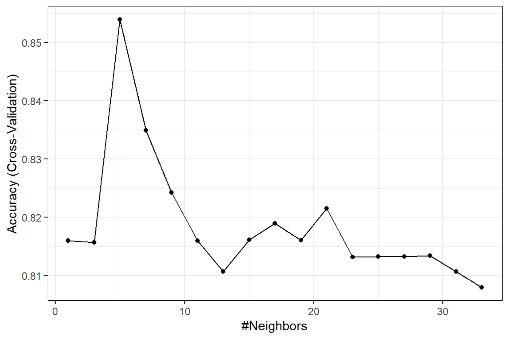

```r
highuse_knn_mod = train(
  factor(high_use) ~ .,
  data = mydata,
  method = "knn",
  trControl = trainControl(method = "cv", number = 10),
  preProcess = c("center", "scale"),
  tuneGrid = expand.grid(k = seq(1, 34, by = 2))
)

ggplot(highuse_knn_mod) + theme_bw()
```

```r
#highuse_knn_mod$bestTune
get_best_result = function(caret_fit) {
  best = which(rownames(caret_fit$results) == rownames(caret_fit$bestTune))
  best_result = caret_fit$results[best, ]
  rownames(best_result) = NULL
  best_result
}
get_best_result(highuse_knn_mod)
```

```
##   k  Accuracy     Kappa AccuracySD   KappaSD
## 1 5 0.8538841 0.5949959 0.04337649 0.1393645
```

*This is the end of the report*

```r
date()
```

```
## [1] "Sun Dec 05 15:48:37 2021"
```

# Chapter 4 Clustering and classification

*Summary of the week (completed work and learning)*

In this Chapter We cover two parts:

- Data analysis: we analyze the Boston data from the MASS package using a linear discriminant analysis on the train set.
- Data wrangling: we create a new R script called create_human.R, “Human development” and “Gender inequality” data into R.

### Part 1: data analysis

In this part, We use the following R packages:

```r
library(ggplot2) # to produce plots
library(GGally)
library(ggpubr)  # this is to combine plots in one frame
library(dplyr)
library(tidyr)   # to plot multiple densities and histograms
library(caret)   # to perform cross validations
```

We then proceed by firstly run the R script, print some outputs and then read the outputs.

## 4.1 Explore the data

We load the Boston data from the MASS package and look at the structure as well as the summary as follows:

```r
# access the MASS package
library(MASS)
```

```r
# load the data
data("Boston")
str(Boston) # explore the structure
```

```
## 'data.frame':    506 obs. of  14 variables:
##  $ crim   : num  0.00632 0.02731 0.02729 0.03237 0.06905 ...
##  $ zn     : num  18 0 0 0 0 0 12.5 12.5 12.5 12.5 ...
##  $ indus  : num  2.31 7.07 7.07 2.18 2.18 2.18 7.87 7.87 7.87 7.87 ...
##  $ chas   : int  0 0 0 0 0 0 0 0 0 0 ...
##  $ nox    : num  0.538 0.469 0.469 0.458 0.458 0.458 0.524 0.524 0.524 0.524 ...
##  $ rm     : num  6.58 6.42 7.18 7 7.15 ...
##  $ age    : num  65.2 78.9 61.1 45.8 54.2 58.7 66.6 96.1 100 85.9 ...
##  $ dis    : num  4.09 4.97 4.97 6.06 6.06 ...
##  $ rad    : int  1 2 2 3 3 3 5 5 5 5 ...
##  $ tax    : num  296 242 242 222 222 222 311 311 311 311 ...
##  $ ptratio: num  15.3 17.8 17.8 18.7 18.7 18.7 15.2 15.2 15.2 15.2 ...
##  $ black  : num  397 397 393 395 397 ...
##  $ lstat  : num  4.98 9.14 4.03 2.94 5.33 ...
##  $ medv   : num  24 21.6 34.7 33.4 36.2 28.7 22.9 27.1 16.5 18.9 ...
```

```r
summary(Boston) #print summary
```

```
##       crim                zn             indus            chas
##  Min.   : 0.00632   Min.   :  0.00   Min.   : 0.46   Min.   :0.00000
##  1st Qu.: 0.08205   1st Qu.:  0.00   1st Qu.: 5.19   1st Qu.:0.00000
##  Median : 0.25651   Median :  0.00   Median : 9.69   Median :0.00000
##  Mean   : 3.61352   Mean   : 11.36   Mean   :11.14   Mean   :0.06917
##  3rd Qu.: 3.67708   3rd Qu.: 12.50   3rd Qu.:18.10   3rd Qu.:0.00000
##  Max.   :88.97620   Max.   :100.00   Max.   :27.74   Max.   :1.00000
##       nox               rm             age              dis
##  Min.   :0.3850   Min.   :3.561   Min.   :  2.90   Min.   : 1.130
##  1st Qu.:0.4490   1st Qu.:5.886   1st Qu.: 45.02   1st Qu.: 2.100
##  Median :0.5380   Median :6.208   Median : 77.50   Median : 3.207
##  Mean   :0.5547   Mean   :6.285   Mean   : 68.57   Mean   : 3.795
##  3rd Qu.:0.6240   3rd Qu.:6.623   3rd Qu.: 94.08   3rd Qu.: 5.188
##  Max.   :0.8710   Max.   :8.780   Max.   :100.00   Max.   :12.127
##       rad              tax           ptratio          black
##  Min.   : 1.000   Min.   :187.0   Min.   :12.60   Min.   :  0.32
##  1st Qu.: 4.000   1st Qu.:279.0   1st Qu.:17.40   1st Qu.:375.38
##  Median : 5.000   Median :330.0   Median :19.05   Median :391.44
##  Mean   : 9.549   Mean   :408.2   Mean   :18.46   Mean   :356.67
##  3rd Qu.:24.000   3rd Qu.:666.0   3rd Qu.:20.20   3rd Qu.:396.23
##  Max.   :24.000   Max.   :711.0   Max.   :22.00   Max.   :396.90
##      lstat            medv
##  Min.   : 1.73   Min.   : 5.00
##  1st Qu.: 6.95   1st Qu.:17.02
##  Median :11.36   Median :21.20
##  Mean   :12.65   Mean   :22.53
##  3rd Qu.:16.95   3rd Qu.:25.00
##  Max.   :37.97   Max.   :50.00
```

**Brief description about the dataset**

This is data of housing Values in Suburbs of Boston. We have 506 observations of 14 variables which the description of each variabel in details can be seen here: https://stat.ethz.ch/R-manual/R-devel/library/MASS/html/Boston.html. From the summary, we can see that there is a wide range of different scales of the variables in the dataset.

## 4.2 Graphical overview

Here, we show a graphical overview of the data. We especially look at the distributions and correlations between the variables. From the histograms and density plots, most variables are not normally distributed and most feature long tails. Among all variables, ‘medv’ and ‘rm’ seem normally distributed. Then from the correlograms, some variables pose a high degree of correlations, both positive and negative correlations. The positive correlations are highlighted by reds, while negative correlations are highlighted with blues. The highest positive correlation is between ‘rad’ and ‘tax’ (0.91) and the highest negative correlation is between ‘nox’ and ‘dis’ (0.77).

```r
data <- Boston %>%                          # Apply pivot_longer function
  pivot_longer(colnames(Boston)) %>%
  as.data.frame()
head(data)                                # Print head of data
```

```
##    name    value
## 1  crim  0.00632
## 2    zn 18.00000
## 3 indus  2.31000
## 4  chas  0.00000
## 5   nox  0.53800
## 6    rm  6.57500
```

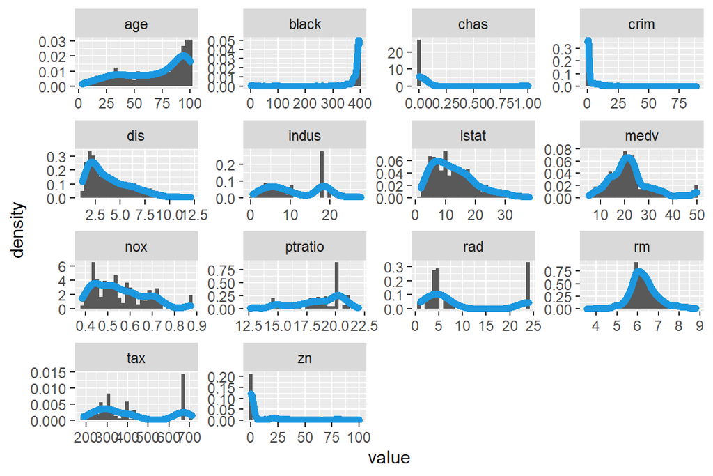

```r
ggp <- ggplot(data, aes(x = value)) +    # Draw histogram & density
  geom_histogram(aes(y = ..density..)) +
  geom_density(col = "#1b98e0", size = 2) +
  facet_wrap(~ name, scales = "free")
ggp
```

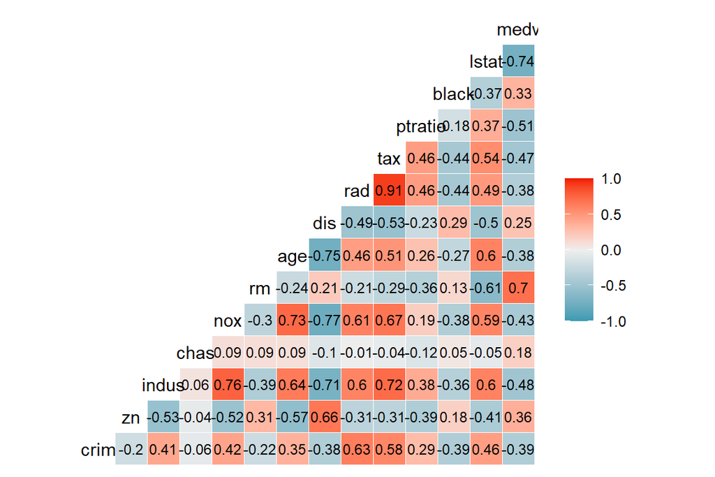

```r
ggcorr(Boston[colnames(Boston) != "gender"], palette = "RdBu", label = TRUE, label_round=2, label_size = 3)
```

## 4.3 Standardize the dataset

We standardize the dataset and print out summaries of the scaled data. From the summary below, we can now see that the means of the variables are all zeros.

```r
data_scaled <- scale(Boston) # Use the standardize package
summary(data_scaled)
```

```
##       crim                 zn               indus              chas
##  Min.   :-0.419367   Min.   :-0.48724   Min.   :-1.5563   Min.   :-0.2723
##  1st Qu.:-0.410563   1st Qu.:-0.48724   1st Qu.:-0.8668   1st Qu.:-0.2723
##  Median :-0.390280   Median :-0.48724   Median :-0.2109   Median :-0.2723
##  Mean   : 0.000000   Mean   : 0.00000   Mean   : 0.0000   Mean   : 0.0000
##  3rd Qu.: 0.007389   3rd Qu.: 0.04872   3rd Qu.: 1.0150   3rd Qu.:-0.2723
##  Max.   : 9.924110   Max.   : 3.80047   Max.   : 2.4202   Max.   : 3.6648
##       nox                rm               age               dis
##  Min.   :-1.4644   Min.   :-3.8764   Min.   :-2.3331   Min.   :-1.2658
##  1st Qu.:-0.9121   1st Qu.:-0.5681   1st Qu.:-0.8366   1st Qu.:-0.8049
##  Median :-0.1441   Median :-0.1084   Median : 0.3171   Median :-0.2790
##  Mean   : 0.0000   Mean   : 0.0000   Mean   : 0.0000   Mean   : 0.0000
##  3rd Qu.: 0.5981   3rd Qu.: 0.4823   3rd Qu.: 0.9059   3rd Qu.: 0.6617
##  Max.   : 2.7296   Max.   : 3.5515   Max.   : 1.1164   Max.   : 3.9566
##       rad               tax             ptratio            black
##  Min.   :-0.9819   Min.   :-1.3127   Min.   :-2.7047   Min.   :-3.9033
##  1st Qu.:-0.6373   1st Qu.:-0.7668   1st Qu.:-0.4876   1st Qu.: 0.2049
##  Median :-0.5225   Median :-0.4642   Median : 0.2746   Median : 0.3808
##  Mean   : 0.0000   Mean   : 0.0000   Mean   : 0.0000   Mean   : 0.0000
##  3rd Qu.: 1.6596   3rd Qu.: 1.5294   3rd Qu.: 0.8058   3rd Qu.: 0.4332
##  Max.   : 1.6596   Max.   : 1.7964   Max.   : 1.6372   Max.   : 0.4406
##      lstat              medv
##  Min.   :-1.5296   Min.   :-1.9063
##  1st Qu.:-0.7986   1st Qu.:-0.5989
##  Median :-0.1811   Median :-0.1449
##  Mean   : 0.0000   Mean   : 0.0000
##  3rd Qu.: 0.6024   3rd Qu.: 0.2683
##  Max.   : 3.5453   Max.   : 2.9865
```

```r
#create a categorical crime rate variable
newcrime <- as.factor(ifelse(data_scaled[1:506, 1] < 0.08205, 'A',
                          ifelse(data_scaled[1:506, 1] < 0.25651, 'B',
                          ifelse(data_scaled[1:506, 1] < 3.61352, 'C',
                          ifelse(data_scaled[1:506, 1] < 3.67708, 'D',0)))))

newdata <- data.frame(newcrime, data_scaled[1:506, 2:14]) # Drop the old crime rate variable & put the new variable into it.
# divide the dataset to train and test sets
## 80% of the sample size
smp_size <- floor(0.80 * nrow(newdata))

## set the seed to make partition reproducible
set.seed(1235)
train_ind <- sample(seq_len(nrow(newdata)), size = smp_size)

train <- newdata[train_ind, ]
test <- newdata[-train_ind, ]
```

## 4.4 Fit the linear discriminant analysis on the train set

Next, we fit a linear discriminant analysis on the train set. We use the categorical crime rate as the target variable and all the other variables in the dataset as predictor variables. We then draw the LDA (bi)plot.

```r
model <- lda(train$newcrime~., data = train)
model
```

```
## Call:
## lda(train$newcrime ~ ., data = train)
##
## Prior probabilities of groups:
##           0           A           B           C
## 0.007425743 0.789603960 0.039603960 0.163366337
##
## Group means:
##           zn      indus        chas        nox          rm        age
## 0 -0.4872402  1.0149946 -0.27232907  0.8368446 -0.44495696  0.8641592
## A  0.1336046 -0.3074741  0.01153709 -0.3266531  0.07706802 -0.2555039
## B -0.4872402  1.0149946 -0.02626030  0.8861063 -0.25264027  0.6137051
## C -0.4872402  1.0149946 -0.15302300  1.0431750 -0.40098715  0.8398297
##          dis        rad        tax    ptratio      black       lstat       medv
## 0 -0.9983375  1.6596029  1.5294129  0.8057784 -3.7685657  0.34032337 -1.1923470
## A  0.2721614 -0.5181641 -0.4588378 -0.2225764  0.2409408 -0.24996379  0.1842050
## B -0.6564289  1.6596029  1.5294129  0.8057784 -0.1946129  0.06643785  0.1731190
## C -0.8858137  1.6596029  1.5294129  0.8057784 -0.9293838  1.10432149 -0.8534722
##
## Coefficients of linear discriminants:
##                  LD1         LD2          LD3
## zn      -0.187111412  0.24260931 -0.058642313
## indus   -0.031929123 -0.23656445  0.299270312
## chas     0.129543544  0.05438082 -0.038986051
## nox      0.328508883 -0.51159946 -0.129243467
## rm      -0.205858348  0.38530001 -0.841695471
## age     -0.010595434 -0.04852834  0.542508694
## dis      0.314054651 -0.70324882  0.286884652
## rad     -2.560614330 -0.17587934 -0.006270611
## tax     -0.011416877 -0.33412105  0.068607228
## ptratio  0.008397258 -0.20252082  0.091169960
## black    0.123918755 -0.80259514 -0.747245493
## lstat   -0.263170522  0.01475087 -1.369044498
## medv     0.188586691 -1.02960331  0.463123736
##
## Proportion of trace:
##    LD1    LD2    LD3
## 0.9580 0.0255 0.0165
```

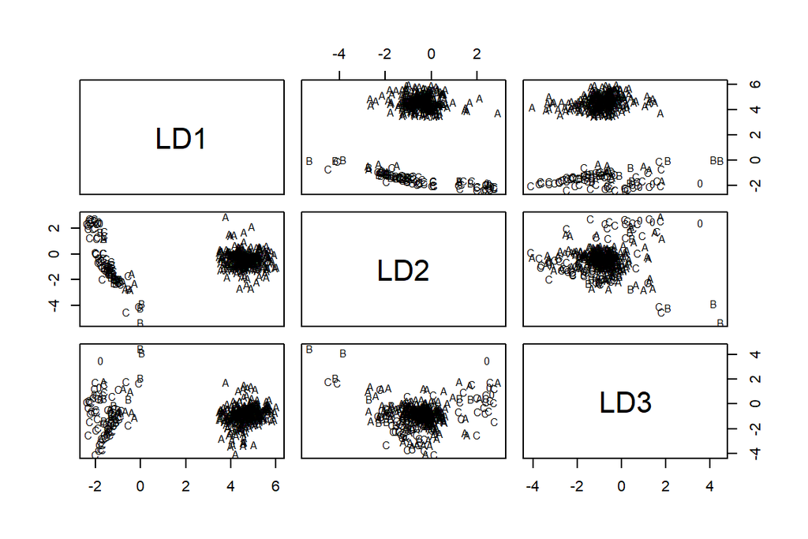

```r
# Draw the LDA (bi)plot
plot(model)
```

## 4.5 Predict with the LDA model

Here, we save the crime categories from the test set and then remove the categorical crime variable from the test dataset. We then predict the classes with the LDA model on the test data and cross tabulate the results with the crime categories from the test set.

```r
# save the crime categories from the test set
crime_test <- test$newcrime
# remove the categorical crime variable from the test dataset.
test <- subset(test, select = -newcrime)
# predict the classes with the LDA model
predictions <- model %>% predict(test)
# cross tabulate the results
table(predictions$class, crime_test)
```

```
##    crime_test
##      0  A  B  C
##   0  0  0  1  2
##   A  0 65  0  0
##   B  0  1  2  2
##   C  5  4  2 18
```

Based on the prediction results above, we have 18+65+2=85 correct predictions or accuracy of 83.33%, hence the error is about 16.67%.

## 4.6 Run k-means algorithm

Here, we reload the Boston dataset and standardize the dataset. We then calculate the distances between the observations. The computation of the distances below is based on Euclidean distance. The visualization is the visualization of the distance matrix which seems posing too large dimensions.

```r
# reload data and standardize
data("Boston")
data <- scale(Boston) # Use the standardize package
```

```r
library(tidyverse)  # for data manipulation
library(cluster)    # for clustering algorithms
library(factoextra) # for clustering algorithms & visualization
```

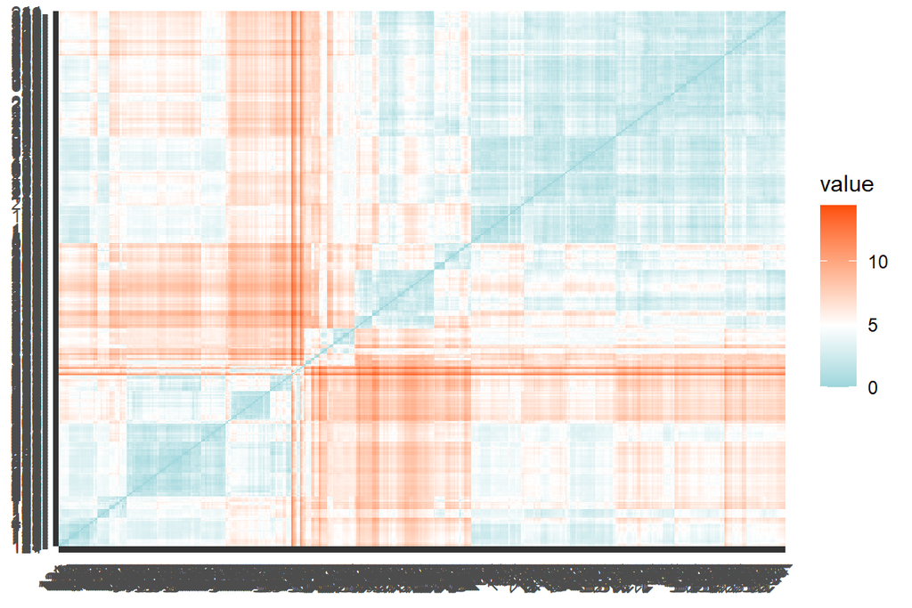

```r
distance <- get_dist(data)
fviz_dist(distance, gradient = list(low = "#00AFBB", mid = "white", high = "#FC4E07"))
```

We now run k-means algorithm on the dataset and investigate what is the optimal number of clusters and run the algorithm again. We adopt some R packages from here: https://uc-r.github.io/kmeans_clustering#distance.

```r
k2 <- kmeans(data, centers = 2, nstart = 25) # k=2 clusters
k3 <- kmeans(data, centers = 3, nstart = 25) # k=3 clusters
k4 <- kmeans(data, centers = 4, nstart = 25) # k=4 clusters
k5 <- kmeans(data, centers = 5, nstart = 25) # k=5 clusters
str(k2)
```

```
## List of 9
##  $ cluster     : Named int [1:506] 2 2 2 2 2 2 2 2 2 2 ...
##   ..- attr(*, "names")= chr [1:506] "1" "2" "3" "4" ...
##  $ centers     : num [1:2, 1:14] 0.724 -0.389 -0.487 0.262 1.143 ...
##   ..- attr(*, "dimnames")=List of 2
##   .. ..$ : chr [1:2] "1" "2"
##   .. ..$ : chr [1:14] "crim" "zn" "indus" "chas" ...
##  $ totss       : num 7070
##  $ withinss    : num [1:2] 1891 2686
##  $ tot.withinss: num 4577
##  $ betweenss   : num 2493
##  $ size        : int [1:2] 177 329
##  $ iter        : int 1
##  $ ifault      : int 0
##  - attr(*, "class")= chr "kmeans"
```

We continue to visualize the clusters. The visualization tells us where true dilineations occur. To evaluate further what the optimal number of clusters is, we rely on the so-called “Average Silhouette Method”. In short, the method measures how well each object lies within its cluster. A high average silhouette width indicates a good clustering. Based on the results, we find that the optimum number of clusters is 2.

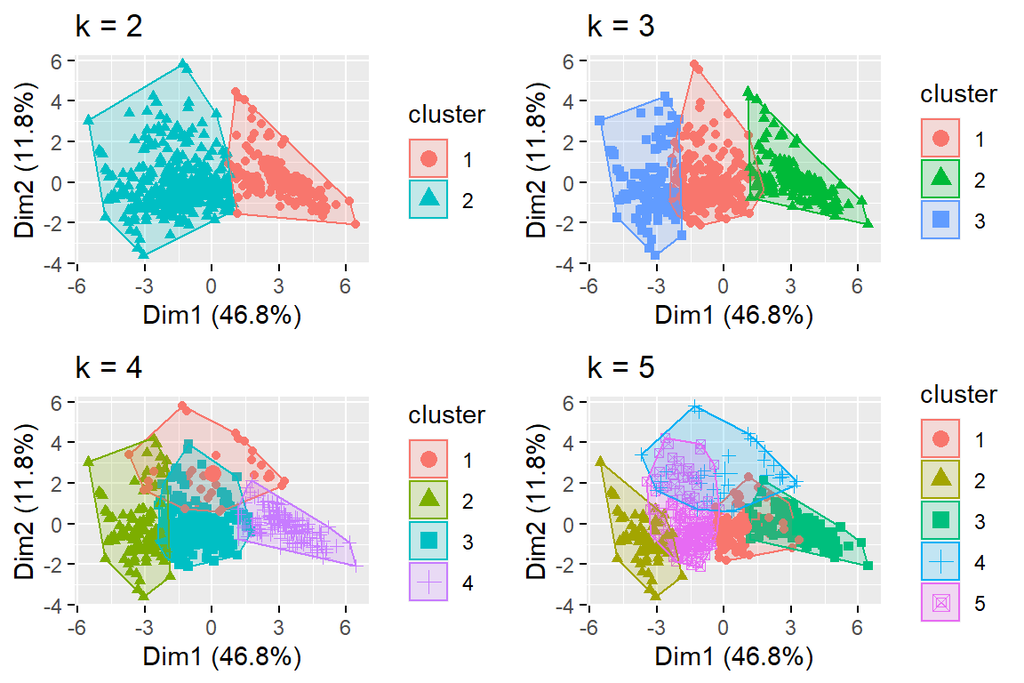

```r
# plots to compare
p1 <- fviz_cluster(k2, geom = "point", data = data) + ggtitle("k = 2")
p2 <- fviz_cluster(k3, geom = "point",  data = data) + ggtitle("k = 3")
p3 <- fviz_cluster(k4, geom = "point",  data = data) + ggtitle("k = 4")
p4 <- fviz_cluster(k5, geom = "point",  data = data) + ggtitle("k = 5")

library(gridExtra)
grid.arrange(p1, p2, p3, p4, nrow = 2)
```

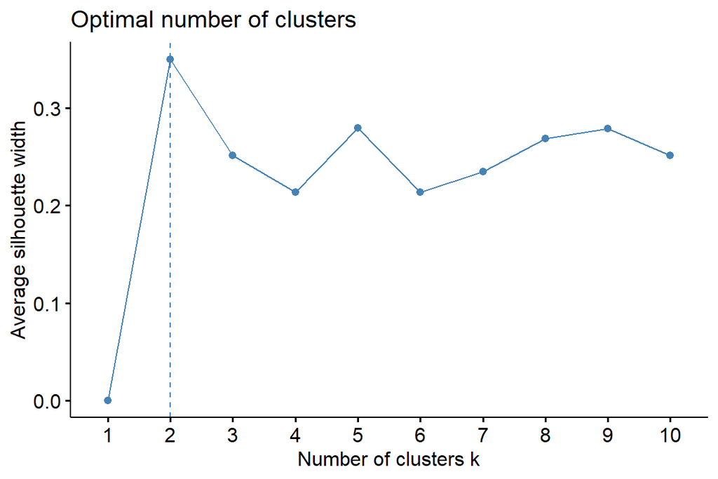

```r
fviz_nbclust(data, kmeans, method = "silhouette")
```

### Part 2: data wrangling

We create a new R script called create_human.R here: https://github.com/alfanmansur/IODS-project/blob/master/data/create_human.R

*This is the end of the report*

```r
date()
```

```
## [1] "Sun Dec 05 15:48:55 2021"
```

# Chapter 5 Dimensionality reduction techniques

*Summary of the week (completed work and learning)*

In this Chapter We cover two parts:

- Part 1 data wrangling: we continue the R script create_human.R.
- Part 2 data analysis: we analyze the data of Human Development Index (HDI) which originates from the United Nations Development Program. We utilize Principal Component Analysis (PCA) and Multiple Correspondence Analysis (MCA) techniques.

We use the following R packages:

```r
library(ggplot2) # to produce plots
library(GGally)
library(ggpubr)  # this is to combine plots in one frame
library(dplyr)
library(tidyr)   # to plot multiple densities and histograms
#library(caret)   # to perform cross validations
```

## 5.1 Graphical overview of the data

The dataset is about Human Development Index (HDI) composed from a number of indicators measuring several various dimensions as described here: http://hdr.undp.org/en/content/human-development-index-hdi and here: http://hdr.undp.org/sites/default/files/hdr2015_technical_notes.pdf for more technical details.

The dataset covers 155 countries and consists of 8 variables, i.e.  
(1) ratio of mean years of education between female and male (“Edu2.FM”)  
(2) ratio of labor force participation rate between female and female (“Labo.FM”)  
(3) life expectancy at birth (“Life.Exp”)  
(4) expected years of education (“Edu.Exp”)  
(5) Gross National Income per capita (“GNI”)  
(6) maternal mortality ratio (“Mat.Mor”)  
(7) adolescent birth rate (“Ado.Birth”), and (8) percentage of female representation in Parliament (“Parli.F”).

We present summaries of the variables in the data below. From the structure of the dataset, all variables are numerical variables of which 7 variables are double precision floating point numbers and 1 variable is integer. Based on the summary, we can see that we have a diverse range of series, except between “Edu2.FM” and “Labo.FM” as both are ratios.

```r
# load the data
human <- read.csv('./data/human.csv', row.names=1)
str(human) # explore the structure
```

```
## 'data.frame':    155 obs. of  8 variables:
##  $ Edu2.FM  : num  1.007 0.997 0.983 0.989 0.969 ...
##  $ Labo.FM  : num  0.891 0.819 0.825 0.884 0.829 ...
##  $ Life.Exp : num  81.6 82.4 83 80.2 81.6 80.9 80.9 79.1 82 81.8 ...
##  $ Edu.Exp  : num  17.5 20.2 15.8 18.7 17.9 16.5 18.6 16.5 15.9 19.2 ...
##  $ GNI      : num  65 42.3 56.4 44 45.4 ...
##  $ Mat.Mor  : int  4 6 6 5 6 7 9 28 11 8 ...
##  $ Ado.Birth: num  7.8 12.1 1.9 5.1 6.2 3.8 8.2 31 14.5 25.3 ...
##  $ Parli.F  : num  39.6 30.5 28.5 38 36.9 36.9 19.9 19.4 28.2 31.4 ...
```

```r
summary(human)
```

```
##     Edu2.FM          Labo.FM          Life.Exp        Edu.Exp
##  Min.   :0.1717   Min.   :0.1857   Min.   :49.00   Min.   : 5.40
##  1st Qu.:0.7264   1st Qu.:0.5984   1st Qu.:66.30   1st Qu.:11.25
##  Median :0.9375   Median :0.7535   Median :74.20   Median :13.50
##  Mean   :0.8529   Mean   :0.7074   Mean   :71.65   Mean   :13.18
##  3rd Qu.:0.9968   3rd Qu.:0.8535   3rd Qu.:77.25   3rd Qu.:15.20
##  Max.   :1.4967   Max.   :1.0380   Max.   :83.50   Max.   :20.20
##       GNI             Mat.Mor         Ado.Birth         Parli.F
##  Min.   :  1.123   Min.   :   1.0   Min.   :  0.60   Min.   : 0.00
##  1st Qu.:  5.275   1st Qu.:  11.5   1st Qu.: 12.65   1st Qu.:12.40
##  Median : 13.054   Median :  49.0   Median : 33.60   Median :19.30
##  Mean   : 46.496   Mean   : 149.1   Mean   : 47.16   Mean   :20.91
##  3rd Qu.: 27.256   3rd Qu.: 190.0   3rd Qu.: 71.95   3rd Qu.:27.95
##  Max.   :908.000   Max.   :1100.0   Max.   :204.80   Max.   :57.50
```

We now display a graphical overview of each variable together with their correlations between them. From the distribution plots, we have only “Edu.Exp” and “Parli.F” which are close to density of a normal distribution.

In terms of the relationships between them, many variables are significantly correlated to each other. The highest positive correlation is between “Edu.Exp” and “Life.Exp” (0.789) and the highest negative correlation is between “Mat.Mor” and “Life.Exp” (-0.857). All the correlations between variables can be seen from the outputs of “ggpairs” and “ggcorr” R packages below.

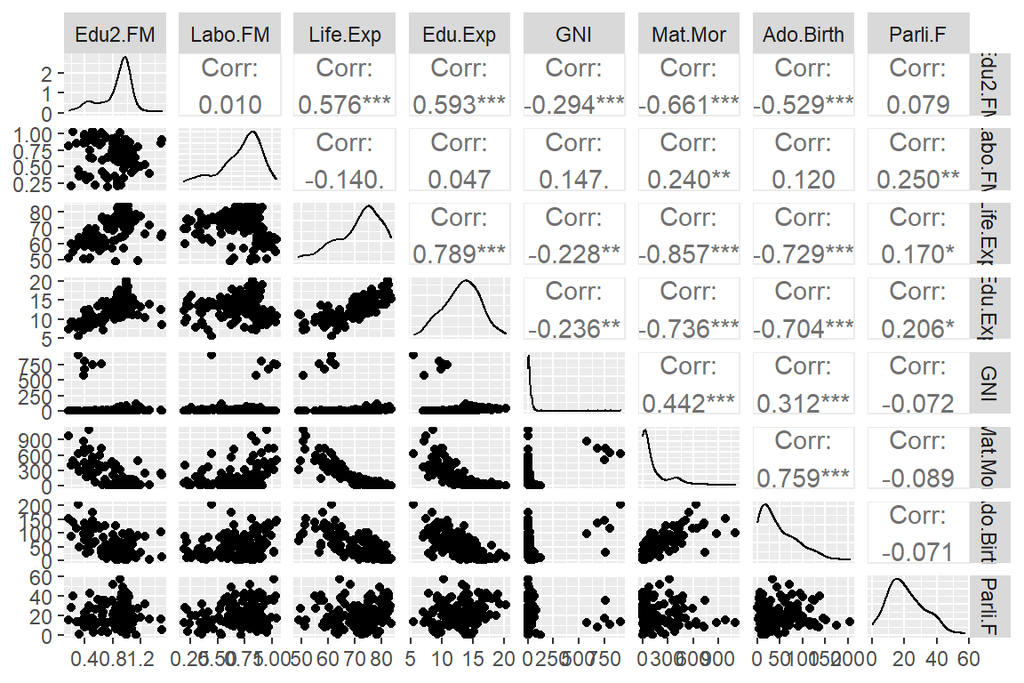

```r
ggpairs(human)
```

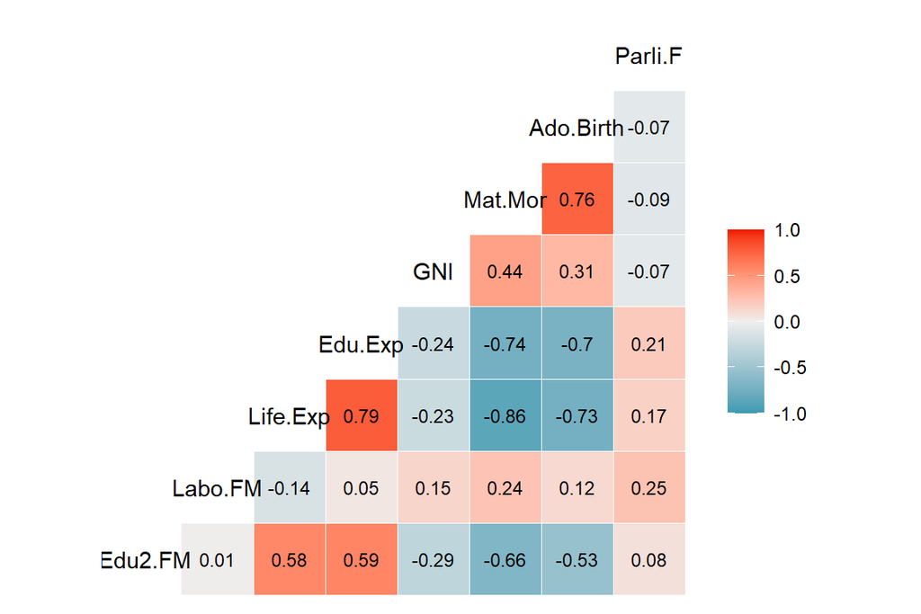

```r
ggcorr(human, palette = "RdBu", label = TRUE, label_round=2, label_size = 3)
```

## 5.2 Perform principal component analysis (PCA)

We continue by performing principal component analysis (PCA) on the originally constructed series (not standardized) of human data. If we look at the summary, the Cumulative Proportion shows that until the second Principal Component (PC2), it is already 98.74%, hence the 8 variables may be reduced to 2 variables only.

```r
pca_human <- prcomp(human)
summary(pca_human)
```

```
## Importance of components:
##                            PC1      PC2      PC3      PC4     PC5     PC6
## Standard deviation     227.566 121.2798 26.48071 11.47526 3.89773 1.60859
## Proportion of Variance   0.769   0.2184  0.01041  0.00196 0.00023 0.00004
## Cumulative Proportion    0.769   0.9874  0.99778  0.99974 0.99996 1.00000
##                           PC7    PC8
## Standard deviation     0.1915 0.1598
## Proportion of Variance 0.0000 0.0000
## Cumulative Proportion  1.0000 1.0000
```

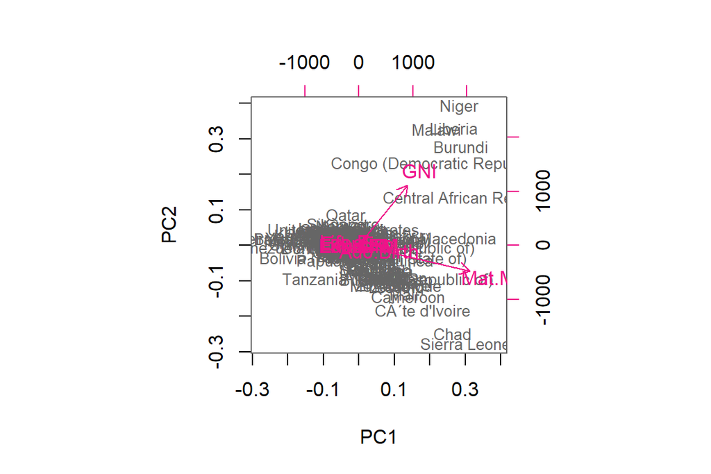

```r
# draw a biplot of the principal component representation and the original variables
biplot(pca_human, choices = 1:2, cex = c(0.8, 1), col = c("grey40", "deeppink2"))
```

```r
# rounded percentages of variance captured by each PC
s <- summary(pca_human)
pca_pr <- round(100*s$importance[2,], digits = 1) #rounded percentages of variance captured by each PC
pca_pr   #print out the percentages of variance
```

```
##  PC1  PC2  PC3  PC4  PC5  PC6  PC7  PC8
## 76.9 21.8  1.0  0.2  0.0  0.0  0.0  0.0
```

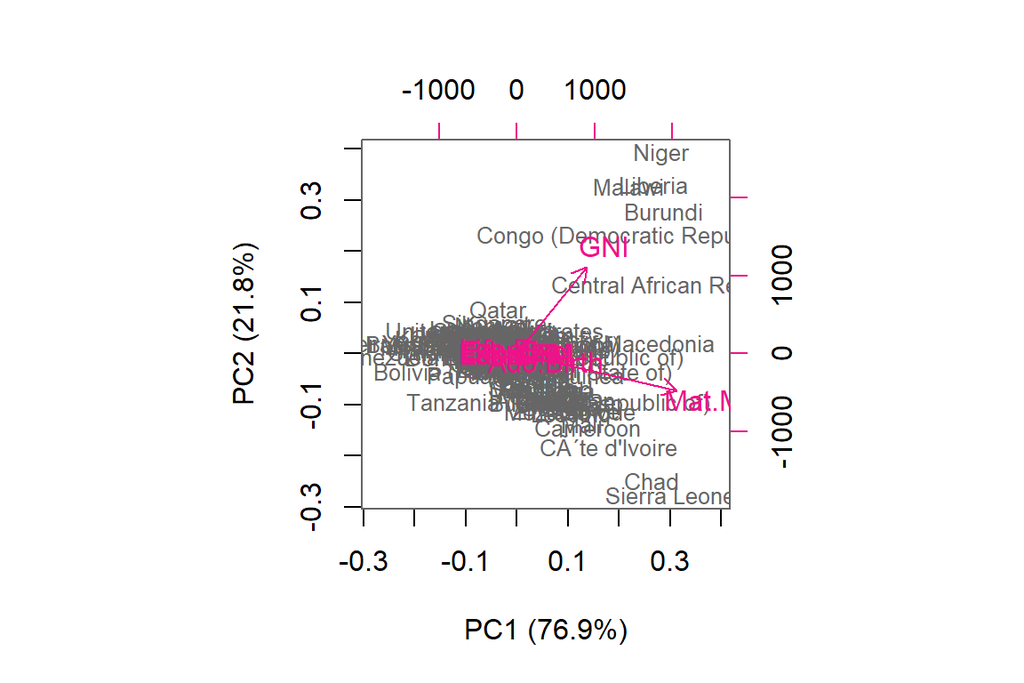

```r
pc_lab <- paste0(names(pca_pr), " (", pca_pr, "%)") #create object pc_lab to be used as axis labels
# draw a biplot
biplot(pca_human, cex = c(0.8, 1), col = c("grey40", "deeppink2"), xlab = pc_lab[1], ylab = pc_lab[2])
```

In the figures above, we show the variability captured by the principal components and we draw a biplot displaying the observations by the first two principal components (PC1 coordinate in x-axis, PC2 coordinate in y-axis), along with arrows representing the original variables. We can see that the first two principal components account for 98.74% proportion.

## 5.3 Standardize the variables and perform PCA

We now standardize the variables in the human data and repeat the principal component analysis.

```r
human_std <- scale(human) #standardize the variables
pca_human_std <- prcomp(human_std)
summary(pca_human_std)
```

```
## Importance of components:
##                           PC1    PC2    PC3     PC4     PC5     PC6     PC7
## Standard deviation     1.9970 1.1465 0.9439 0.85645 0.69002 0.53246 0.46511
## Proportion of Variance 0.4985 0.1643 0.1114 0.09169 0.05952 0.03544 0.02704
## Cumulative Proportion  0.4985 0.6628 0.7742 0.86585 0.92536 0.96080 0.98784
##                            PC8
## Standard deviation     0.31184
## Proportion of Variance 0.01216
## Cumulative Proportion  1.00000
```

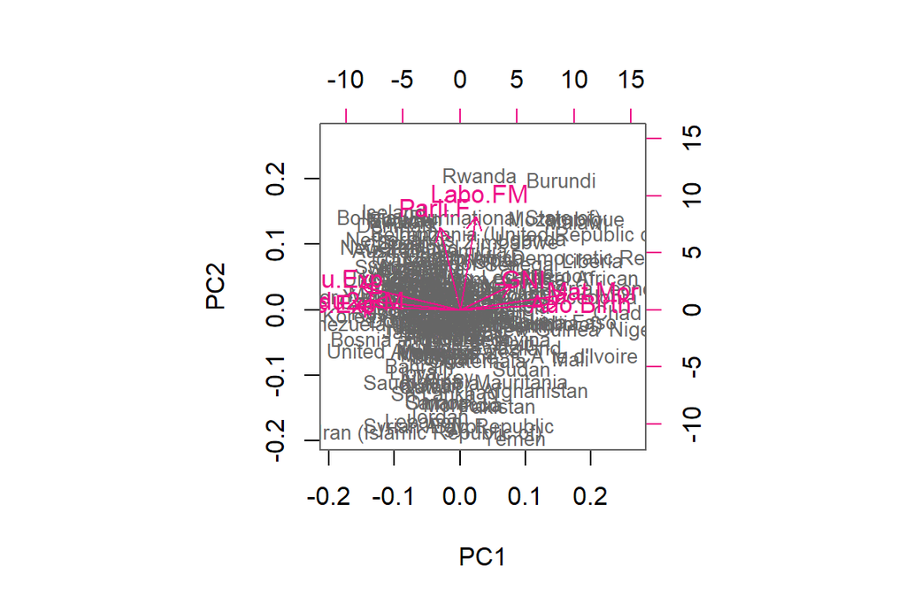

```r
# draw a biplot of the principal component representation and the original variables
biplot(pca_human_std, choices = 1:2, cex = c(0.8, 1), col = c("grey40", "deeppink2"))
```

```r
# rounded percentages of variance captured by each PC
s <- summary(pca_human_std)
pca_pr <- round(100*s$importance[2,], digits = 1) #rounded percentages of variance captured by each PC
pca_pr   #print out the percentages of variance
```

```
##  PC1  PC2  PC3  PC4  PC5  PC6  PC7  PC8
## 49.8 16.4 11.1  9.2  6.0  3.5  2.7  1.2
```

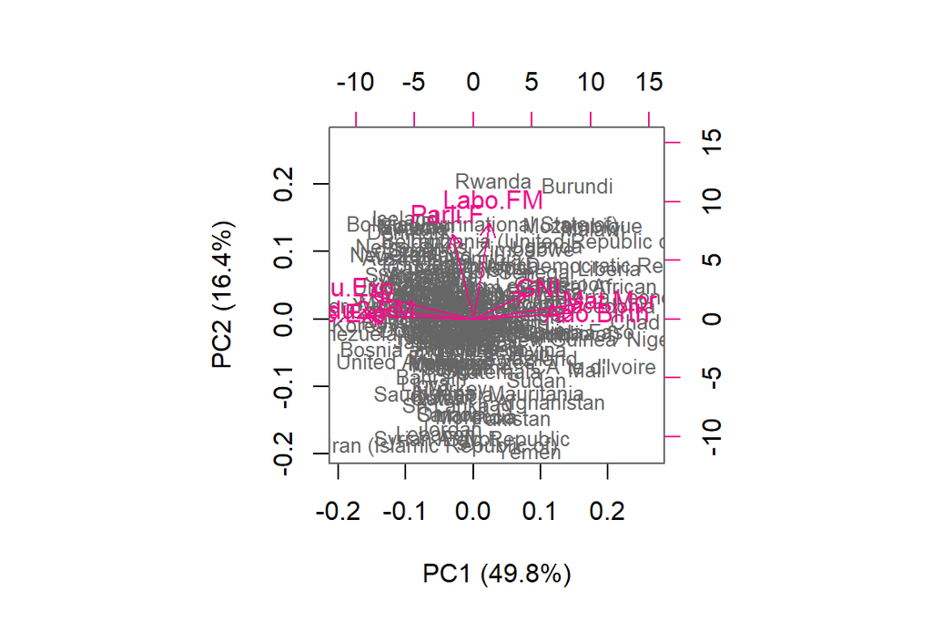

```r
pc_lab <- paste0(names(pca_pr), " (", pca_pr, "%)") #create object pc_lab to be used as axis labels
# draw a biplot
biplot(pca_human_std, cex = c(0.8, 1), col = c("grey40", "deeppink2"), xlab = pc_lab[1], ylab = pc_lab[2])
```

Comparing both analysis (with and without standardizing), we can see somewhat different results. Without standardizing, the first two principal components already account for 98.74%. However, now with standardizing, it needs 7 principal components to account for 98.79% of the whole variance. It means that with standardizing, the 8-variable model can now only be reduced to 7 variables. If we look again the densities of the variables in the beginning, variables “GNI” and “Mat.Mor” are the two variables that feature the most non-normal distributions and we can see the divergence of these two variables in the biplot of the one without standardizing. With standardizing, it is not the case since all variables are now normally distributed with zero mean and unit variance. Hence, the results from with and without standardizing are different.

## 5.4 Personal interpretations

Here we focus to interpret the biplot of the PCA on the standardized data. The plot shows the first two principal component scores and the loading vectors in a single biplot display. First, the two components (PC1 and PC2) account for 66.28% of the total variability of the whole 8-variable model where PC1 explains 49.8% of variance and PC2 explains 16.4% of the variance. Second, it seems that PCA output is concentrated more on positive side. Then, the arrows are plotted at a scale related to the maximum ratio between the scaled eigenvectors of each of the two principal components and their respective scaled scores (the ratio).

## 5.5 The tea dataset from the package ‘Factominer’

We now load the tea dataset from the package Factominer. We explore the data briefly by looking at the structure and the dimensions of the data and then visualize it.

```r
library(FactoMineR)
library(factoextra)
```

```r
data("tea") #load the tea dataset
str(tea) #explore the structure
summary(tea)
dim(tea) #300 obs. of 36 variables
```

[output not shown]

We can group the data into three groups:

1. Integer variables: “age” and “age_Q”.
2. Variables with 2 categories (yes/not): “breakfast”, “tea.time”, “evening”, “lunch”, “dinner”, “always”, “home”, “work”, “tearoom”, “friends”, “resto”, “pub”, “sugar”, “sex”, “Sport”, “escape.exoticism”, “spirituality”, “healthy”, “diuretic”, “friendliness”, “iron.absorption”, “feminine”, “sophisticated”, “slimming”, “exciting”, “relaxing”, “effect.on.health”.
3. Variables with more than 2 categories: “Tea”, “How”, “how”, “where”, “price”, “SPC”, “frequency”.

We then Visualize the tea data here:

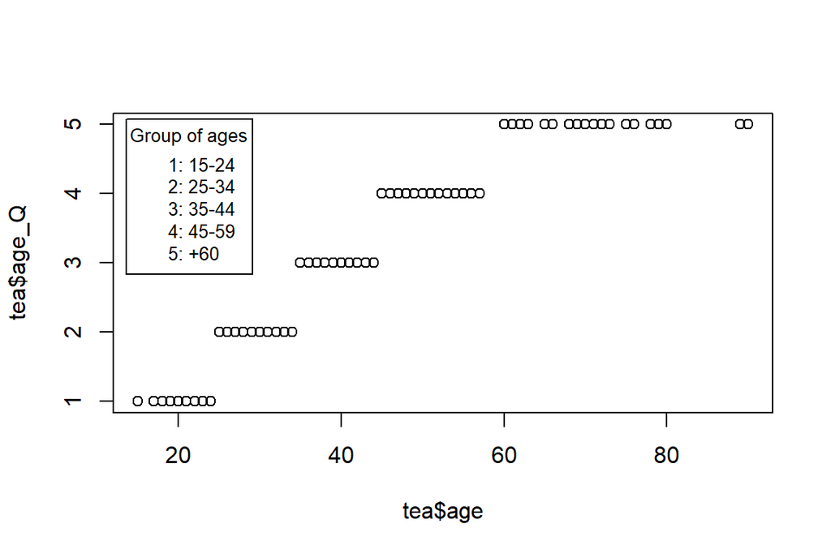

```r
group1 <- c("age", "age_Q")
group2 <- c("breakfast", "tea.time", "evening", "lunch", "dinner", "always", "home", "work", "tearoom", "friends", "resto", "pub", "sugar", "sex", "Sport", "escape.exoticism", "spirituality", "healthy", "diuretic", "friendliness", "iron.absorption", "feminine", "sophisticated", "slimming", "exciting", "relaxing", "effect.on.health")
group3 <- c("Tea", "How", "how", "where", "price", "SPC", "frequency")

#Visualize group 1
plot(tea$age,tea$age_Q)
legend("topleft", inset=.02, title="Group of ages",
   c("1: 15-24","2: 25-34","3: 35-44","4: 45-59","5: +60"), horiz=FALSE, cex=0.8)
```

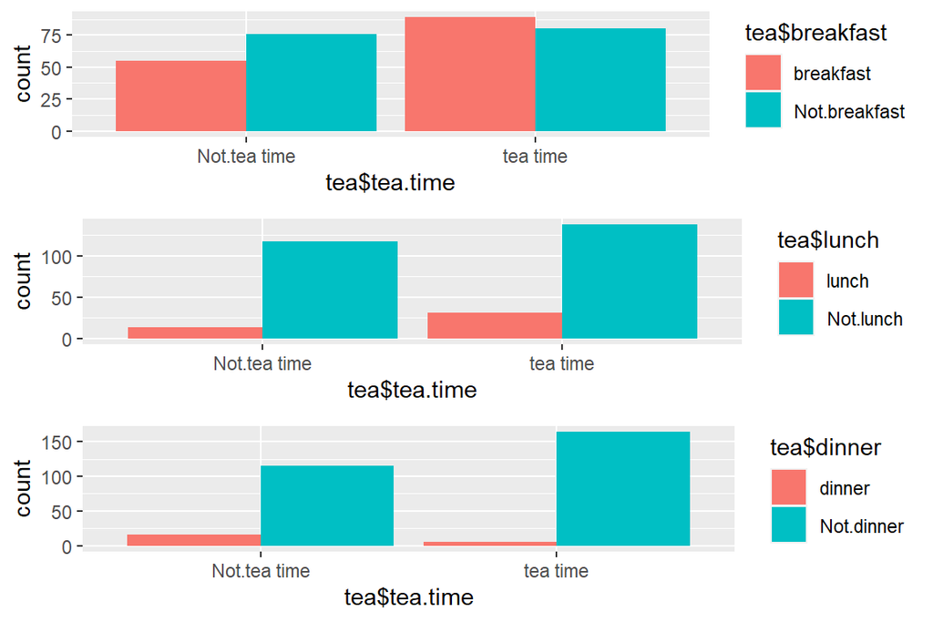

```r
#Visualize group 2 (selected variables)

breakfast <- data.frame(tea$tea.time,tea$breakfast)
eat1 = ggplot(breakfast, aes(tea$tea.time, ..count..)) + geom_bar(aes(fill = tea$breakfast), position = "dodge")
lunch <- data.frame(tea$tea.time,tea$lunch)
eat2 = ggplot(lunch, aes(tea$tea.time, ..count..)) + geom_bar(aes(fill = tea$lunch), position = "dodge")
dinner <- data.frame(tea$tea.time,tea$dinner)
eat3 = ggplot(dinner, aes(tea$tea.time, ..count..)) + geom_bar(aes(fill = tea$dinner), position = "dodge")

ggarrange(eat1, eat2, eat3,
          ncol = 1, nrow = 3)
```

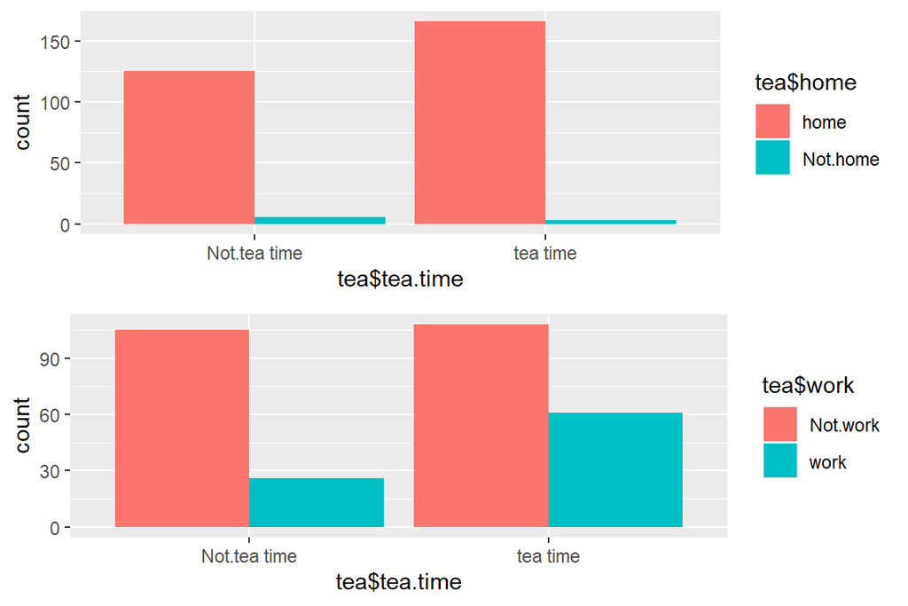

```r
#Visualize group 2 (selected variables)
home <- data.frame(tea$tea.time,tea$home)
at1 = ggplot(home, aes(tea$tea.time, ..count..)) + geom_bar(aes(fill = tea$home), position = "dodge")
work <- data.frame(tea$tea.time,tea$work)
at2 = ggplot(work, aes(tea$tea.time, ..count..)) + geom_bar(aes(fill = tea$work), position = "dodge")

ggarrange(at1, at2,
          ncol = 1, nrow = 2)
```

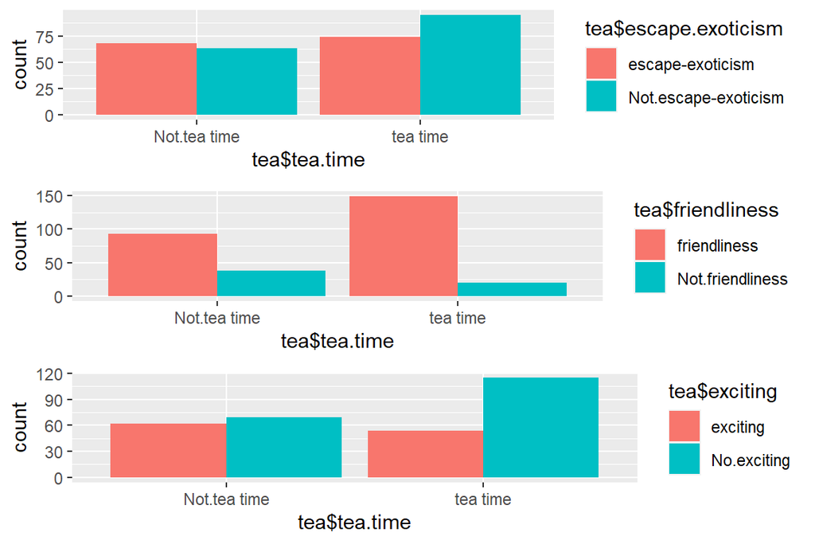

```r
#Visualize group 2 (selected variables)

f1 <- data.frame(tea$tea.time,tea$escape.exoticism)
feel1 = ggplot(f1, aes(tea$tea.time, ..count..)) + geom_bar(aes(fill = tea$escape.exoticism), position = "dodge")
f2 <- data.frame(tea$tea.time,tea$friendliness)
feel2 = ggplot(f2, aes(tea$tea.time, ..count..)) + geom_bar(aes(fill = tea$friendliness), position = "dodge")
f3 <- data.frame(tea$tea.time,tea$exciting)
feel3 = ggplot(f3, aes(tea$tea.time, ..count..)) + geom_bar(aes(fill = tea$exciting), position = "dodge")

ggarrange(feel1, feel2, feel3,
          ncol = 1, nrow = 3)
```

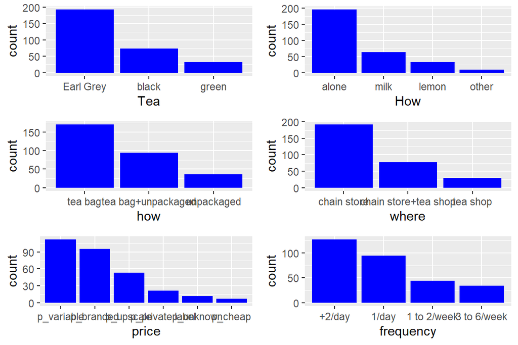

```r
#Visualize group 3 (selected variables)
group3 <- c("Tea", "How", "how", "where", "price", "SPC", "frequency")

br = ggplot(tea, aes(x=reorder(Tea, Tea, function(x)-length(x)))) +
geom_bar(fill='blue') +  labs(x='Tea')
tt = ggplot(tea, aes(x=reorder(How, How, function(x)-length(x)))) +
geom_bar(fill='blue') +  labs(x='How')
ev = ggplot(tea, aes(x=reorder(how, how, function(x)-length(x)))) +
geom_bar(fill='blue') +  labs(x='how')
lu = ggplot(tea, aes(x=reorder(where, where, function(x)-length(x)))) +
geom_bar(fill='blue') +  labs(x='where')
din = ggplot(tea, aes(x=reorder(price, price, function(x)-length(x)))) +
geom_bar(fill='blue') +  labs(x='price')
fr = ggplot(tea, aes(x=reorder(frequency, frequency, function(x)-length(x)))) +
geom_bar(fill='blue') +  labs(x='frequency')

ggarrange(br, tt, ev, lu, din, fr,
          ncol = 2, nrow = 3)
```

We now perform Multiple Correspondence Analysis (MCA) on the tea data (to a certain columns of the data: only 6 columns of “Tea”, “How”, “how”, “sugar”, “where”, “breakfast”).

MCA is generally used to analyze a data set from survey. The goal is to identify: (1) A group of individuals with similar profile in their answers to the questions; and (2) The associations between variable categories. (Source: http://www.sthda.com/english/articles/31-principal-component-methods-in-r-practical-guide/114-mca-multiple-correspondence-analysis-in-r-essentials/)

```r
# Multiple Correspondence Analysis on the tea data

teatime <- data.frame(tea$Tea,tea$How,tea$how,tea$sugar,tea$where,tea$breakfast)
summary(teatime)
```

```
##       tea.Tea     tea.How                  tea.how       tea.sugar
##  black    : 74   alone:195   tea bag           :170   No.sugar:155
##  Earl Grey:193   lemon: 33   tea bag+unpackaged: 94   sugar   :145
##  green    : 33   milk : 63   unpackaged        : 36
##                  other:  9
##                 tea.where         tea.breakfast
##  chain store         :192   breakfast    :144
##  chain store+tea shop: 78   Not.breakfast:156
##  tea shop            : 30
##
```

```r
str(teatime)
```

```
## 'data.frame':    300 obs. of  6 variables:
##  $ tea.Tea      : Factor w/ 3 levels "black","Earl Grey",..: 1 1 2 2 2 2 2 1 2 1 ...
##  $ tea.How      : Factor w/ 4 levels "alone","lemon",..: 1 3 1 1 1 1 1 3 3 1 ...
##  $ tea.how      : Factor w/ 3 levels "tea bag","tea bag+unpackaged",..: 1 1 1 1 1 1 1 1 2 2 ...
##  $ tea.sugar    : Factor w/ 2 levels "No.sugar","sugar": 2 1 1 2 1 1 1 1 1 1 ...
##  $ tea.where    : Factor w/ 3 levels "chain store",..: 1 1 1 1 1 1 1 1 2 2 ...
##  $ tea.breakfast: Factor w/ 2 levels "breakfast","Not.breakfast": 1 1 2 2 1 2 1 2 1 1 ...
```

```r
# multiple correspondence analysis
mca <- MCA(teatime, graph = FALSE)

# summary of the model
summary(mca)
```

```
##
## Call:
## MCA(X = teatime, graph = FALSE)
##
##
## Eigenvalues
##                        Dim.1   Dim.2   Dim.3   Dim.4   Dim.5   Dim.6   Dim.7
## Variance               0.280   0.266   0.216   0.195   0.176   0.157   0.144
## % of var.             15.275  14.487  11.793  10.632   9.574   8.543   7.840
## Cumulative % of var.  15.275  29.762  41.555  52.187  61.761  70.305  78.145
##                        Dim.8   Dim.9  Dim.10  Dim.11
## Variance               0.135   0.116   0.087   0.062
## % of var.              7.386   6.347   4.728   3.394
## Cumulative % of var.  85.531  91.878  96.606 100.000
##
## Individuals (the 10 first)
##                       Dim.1    ctr   cos2    Dim.2    ctr   cos2    Dim.3
## 1                  | -0.307  0.112  0.080 | -0.155  0.030  0.020 |  0.385
## 2                  | -0.299  0.106  0.053 |  0.137  0.024  0.011 |  0.889
## 3                  | -0.294  0.103  0.121 | -0.413  0.214  0.239 |  0.116
## 4                  | -0.441  0.232  0.265 | -0.499  0.312  0.339 | -0.322
## 5                  | -0.372  0.165  0.187 | -0.182  0.042  0.045 |  0.264
## 6                  | -0.294  0.103  0.121 | -0.413  0.214  0.239 |  0.116
## 7                  | -0.372  0.165  0.187 | -0.182  0.042  0.045 |  0.264
## 8                  | -0.221  0.058  0.029 | -0.093  0.011  0.005 |  0.741
## 9                  | -0.018  0.000  0.000 |  1.025  1.318  0.554 |  0.018
## 10                 |  0.335  0.134  0.063 |  0.931  1.088  0.488 |  0.510
##                       ctr   cos2
## 1                   0.228  0.126 |
## 2                   1.218  0.467 |
## 3                   0.021  0.019 |
## 4                   0.160  0.141 |
## 5                   0.108  0.094 |
## 6                   0.021  0.019 |
## 7                   0.108  0.094 |
## 8                   0.846  0.329 |
## 9                   0.000  0.000 |
## 10                  0.402  0.147 |
##
## Categories (the 10 first)
```

[output cut: 16 more lines]

```
## lemon                2.699 |  -1.536  20.002   0.292  -9.336 |
## milk                 3.129 |   0.284   1.309   0.021   2.535 |
## other                6.553 |   1.473   5.018   0.067   4.479 |
## tea bag             -7.795 |   0.110   0.530   0.016   2.179 |
## tea bag+unpackaged  11.426 |  -0.203   0.998   0.019  -2.374 |
## unpackaged          -4.422 |   0.011   0.001   0.000   0.067 |
##
## Categorical variables (eta2)
##                      Dim.1 Dim.2 Dim.3
## tea.Tea            | 0.130 0.128 0.447 |
## tea.How            | 0.081 0.241 0.348 |
## tea.how            | 0.704 0.445 0.020 |
## tea.sugar          | 0.055 0.018 0.373 |
## tea.where          | 0.695 0.635 0.067 |
## tea.breakfast      | 0.016 0.127 0.043 |
```